# Phenoflow analysis

Ruben Props

27 december 2016

Exploratory analysis for Liah Coggins.

# Description of data:

*I only have one sample for each location, but I have 3 time points and for these I have 2 ponds (P1/P2) at the inlet and outlet, and the splitter (SP) (i.e., there are 5 files for each date). I have also included unstained samples that were run for each one (if required). E.g., `T1_P1_I`` = timepoint 1, pond 1, inlet. Also, O = outlet, SP = splitter, and an appended U = unstained. There are also files for cultures I run, one of E. coli, one of cultured wastewater (WW), and one of purple phototrophic bacteria (PPB), should these be useful to you.*

# Load libraries

```r
library("Phenoflow")
library("dplyr")
library("gridExtra")
```

```r
library("grid")
library("ggplot2")
library("RColorBrewer")
source("functions.R")
# Settings for xyplot
my.settings <- list(
  strip.background=list(col="transparent"),
  strip.border=list(col="transparent", cex=5),
  gate=list(col=c("black"),fill="lightblue", alpha=0.5,lwd=4),
  panel.background=list(col="lightgray"),
  background=list(col="white"))
```

# Analysis

Here we follow the standard analysis workflow described here: https://github.com/rprops/Phenoflow_package/wiki/Phenotypic-diversity-analysis.

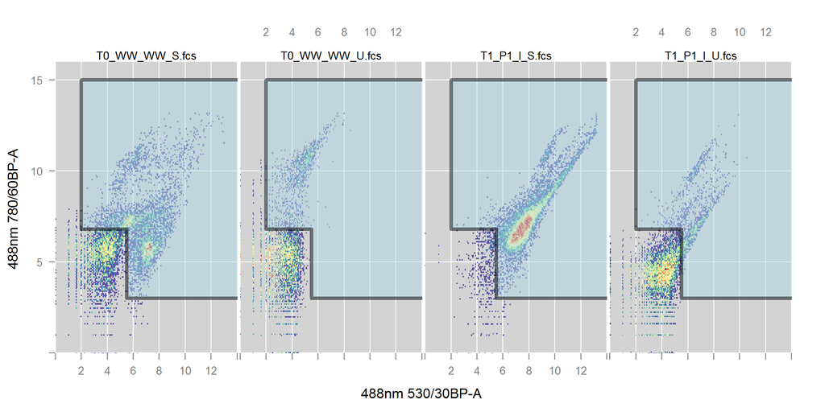

```r
# Import data
path = "data"
flowData <- read.flowSet(path = path, transformation = FALSE, pattern=".fcs")

# Select the channels of interest
flowData_transformed <- transform(flowData,`488nm 530/30BP-A`=asinh(`488nm 530/30BP-A`),
                                  `SSC-A`=asinh(`SSC-A`),
                                  `488nm 780/60BP-A`=asinh(`488nm 780/60BP-A`),
                                  `FSC-A`=asinh(`FSC-A`))
param=c("488nm 530/30BP-A", "488nm 780/60BP-A","SSC-A","FSC-A")
flowData_transformed = flowData_transformed[,param]
remove(flowData)

# Create a PolygonGate for denoising the dataset
sqrcut1 <- matrix(c(5.5,5.5,2,2,15,15,
                    3,6.8,6.8,15,15,3),ncol=2, nrow=6)
colnames(sqrcut1) <- c("488nm 530/30BP-A","488nm 780/60BP-A")
polyGate1 <- polygonGate(.gate=sqrcut1, filterId = "Total Cells")

# Use 4 samples to evaluate the gate
# Unfortunately there is still some spillover from potential (in)organics in certain samples. But if we want to have a consistent gating strategy, this is unavoidable.
xyplot(`488nm 780/60BP-A`~`488nm 530/30BP-A`, data=flowData_transformed[5:8],
       filter=polyGate1,
       xbins=200,
       smooth=FALSE, xlim=c(0,14),ylim=c(0,16),
       par.settings=my.settings,
       margin=FALSE
      )
```

```r
# Isolate only the cellular information based on the polyGate1
flowData_transformed <- Subset(flowData_transformed, polyGate1)

# Normalize all data based on the max 488nm 530/30BP-A intensity
summary <- fsApply(x=flowData_transformed,FUN=function(x) apply(x, 2, max),use.exprs=TRUE)
max = max(summary[,1])
mytrans <- function(x) x/max
flowData_transformed <- transform(flowData_transformed,`488nm 530/30BP-A`=mytrans(`488nm 530/30BP-A`),
                                  `488nm 780/60BP-A`=mytrans(`488nm 780/60BP-A`),
                                  `SSC-A`=mytrans(`SSC-A`),
                                  `FSC-A`=mytrans(`FSC-A`))
```

Now that we’ve imported, denoised and normalized the data, we only proceed with the stained data. Based on the sample names we extract the metadata. We also resample to the minimum sample size to account for sample size effects. This is necessary for sample sizes < 10,000.

```r
# Extract metadata from sample names
meta <-strsplit(gsub(flowCore::sampleNames(flowData_transformed), pattern=".fcs", replacement=""), "_")
meta <- data.frame(do.call(rbind,meta))
colnames(meta) <- c("Timepoint", "Pond", "Position", "Staining")
head(meta)
```

```
##   Timepoint  Pond Position Staining
## 1        T0 Ecoli   Axenic        S
## 2        T0 Ecoli   Axenic        U
## 3        T0   PPB   Axenic        S
## 4        T0   PPB   Axenic        U
## 5        T0    WW       WW        S
## 6        T0    WW       WW        U
```

```r
# Select the stained data
flowData_transformed <- flowData_transformed[meta$Staining == "S"]

# Resample to minimum sample size
flowData_transformed <- FCS_resample(flowData_transformed, replace = TRUE)
```

```
## Your samples range between 5028 and 11841 cells
## Your samples were randomly subsampled to 5028 cells
```

We are now ready to run the alpha-diversity analysis. Restricted the number of bootstraps to 10 for the sake of computational speed.

```r
# Run alpha diversity analysis
Diversity.ww <- Diversity_rf(flowData_transformed, d=3, param = param, R = 10)
```

```
## Mon Feb 27 13:57:34 2017 ---- Starting resample run 1
## Mon Feb 27 13:57:41 2017 ---- Starting resample run 2
## Mon Feb 27 13:57:46 2017 ---- Starting resample run 3
## Mon Feb 27 13:57:53 2017 ---- Starting resample run 4
## Mon Feb 27 13:57:59 2017 ---- Starting resample run 5
## Mon Feb 27 13:58:05 2017 ---- Starting resample run 6
## Mon Feb 27 13:58:11 2017 ---- Starting resample run 7
## Mon Feb 27 13:58:18 2017 ---- Starting resample run 8
## Mon Feb 27 13:58:26 2017 ---- Starting resample run 9
## Mon Feb 27 13:58:34 2017 ---- Starting resample run 10
## Mon Feb 27 13:58:40 2017 ---- Alpha diversity metrics (D0,D1,D2) have been computed after 10 bootstraps
```

```r
# Merge results with metadata
results <- data.frame(Diversity.ww, meta[meta$Staining=="S",])
```

Next perform the beta-diversity analysis with only the Pond/Splitter samples (remove axenic cultures/WW)

```r
# Select the required samples
flowData_beta <- flowData_transformed[-c(1:3)]

# Create fingerprint
fbasis <- flowBasis(flowData_beta, nbin=128, param=param, bw=0.01)

# Calculate PCoA
beta <- beta_div_fcm(fbasis, ord.type="PCoA")

# Calculate variance explained by axes
var <- round(vegan::eigenvals(beta)/sum(vegan::eigenvals(beta))*100,1)

# Merge results with metadata
beta_results <- data.frame(beta$points, meta[meta$Timepoint!="T0" & meta$Staining =="S",])
```

Finally lets make some contrasts between the fingerprints of P1 and P2 at timepoints T1 and T3 to see if there are different populations visible.

```r
### Lets make some contrasts between the ponds
# P1 vs. P2 at timepoint 0
ct1 <- fp_contrasts(fbasis, comp1=beta_results$Pond=="P1" & beta_results$Timepoint=="T1", comp2=beta_results$Pond=="P2" & beta_results$Timepoint=="T1", param=param[1:2],
                    thresh = 0.1)
```

```
##  Region used for contrasts 1 16384
##  Returning contrasts for T1_P1_I_S.fcs T1_P2_I_S.fcs
##      Returning contrasts for T1_P1_O_S.fcs T1_P2_O_S.fcs
```

```r
# P1 vs. P2 at timepoint 3
ct2 <- fp_contrasts(fbasis, comp1=beta_results$Pond=="P1" & beta_results$Timepoint=="T3", comp2=beta_results$Pond=="P2" & beta_results$Timepoint=="T3", param=param[1:2],
                    thresh = 0.1)
```

```
##  Region used for contrasts 1 16384
##  Returning contrasts for T3_P1_I_S.fcs T3_P2_I_S.fcs
##      Returning contrasts for T3_P1_O_S.fcs T3_P2_O_S.fcs
```

The analyses are done, now lets plot the results.

**Primary conclusions from the alpha-diversity analysis:**  
Wastewater has the highest diversity, the pure strains have the lowest diversity, as expected (I’ve plotted these at timepoint 0). There is a shift in alpha-diversity visible. Pond2 and the splitter start at relatively low diversity but they increase over time, with the splitter community having the highest diversity at T3.

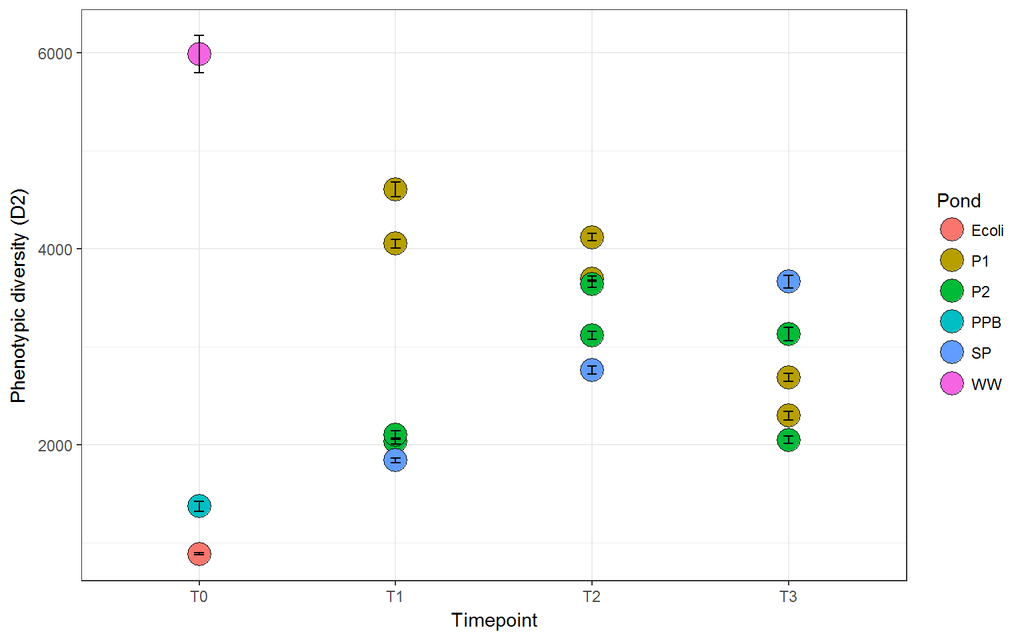

```r
a1 <- ggplot(data=results, aes(x=Timepoint,y=D2,fill=Pond))+
  geom_point(shape=21, size=6)+
  scale_color_brewer(palette="Accent")+
  geom_errorbar(aes(ymin=D2-sd.D2, ymax=D2+sd.D2), width=0.05)+
  theme_bw()+
  labs(y="Phenotypic diversity (D2)", x="Timepoint")

print(a1)
```

**Primary conclusions from the beta-diversity analysis:**  
The difference between inlet and outlet becomes larger over time. The communities are really similar at T1 but differ more at T2/T3. There is a temporal shift noticeable as well for both the splitter as the ponds. Pond 2 starts out really similar to the splitter community but becomes much more similar to pond1 at T2/T3. Diversity of pond 1 is quite high at T1 but decrease to comparable values with P2/SP at T3. Overall the SP community remains relatively stable.

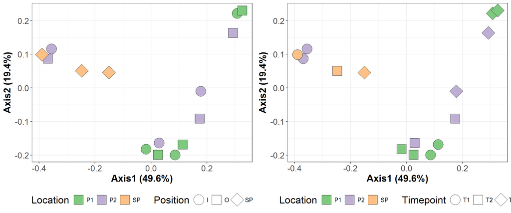

```r
b1 <- ggplot(data=beta_results, aes(x=X1, y=X2, fill=Pond, shape=Position))+
  scale_shape_manual(values=c(21:25,8))+
  geom_point(size=8)+
  theme_bw()+
  scale_fill_brewer(palette="Accent")+
  labs(x = paste0("Axis1 (",var[1], "%)"), y = paste0("Axis2 (",var[2], "%)"),
       fill="Location", shape="Position")+
  theme(axis.text=element_text(size=14), axis.title=element_text(size=16,face="bold"),
        title=element_text(size=17), legend.text=element_text(size=10),
        legend.position = "bottom")+
  guides(fill = guide_legend(override.aes = list(shape = 22)))

b2 <- ggplot(data=beta_results, aes(x=X1, y=X2, fill=Pond, shape=Timepoint))+
  scale_shape_manual(values=c(21:25,8))+
  geom_point(size=8)+
  theme_bw()+
  scale_fill_brewer(palette="Accent")+
  labs(x = paste0("Axis1 (",var[1], "%)"), y = paste0("Axis2 (",var[2], "%)"),
       fill="Location", shape="Timepoint")+
  theme(axis.text=element_text(size=14), axis.title=element_text(size=16,face="bold"),
        title=element_text(size=17), legend.text=element_text(size=10),
        legend.position = "bottom")+
  guides(fill = guide_legend(override.aes = list(shape = 22)))

# png("beta_div.png", width = 12, height = 6, res = 500, units = "in", pointsize = 6)
grid.arrange(b1, b2, ncol=2)
```

```r
# dev.off()
```

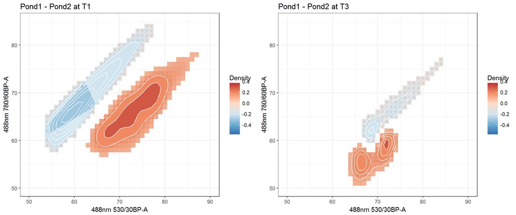

```r
### Plot contrasts
### Red/positive values indicate higher density for pond1.
### blue/negative values indicate lower density for pond1.
v1 <- ggplot2::ggplot(ct1, ggplot2::aes(`488nm 530/30BP-A`, `488nm 780/60BP-A`, z = Density))+
  ggplot2::geom_tile(ggplot2::aes(fill=Density)) +
  ggplot2::geom_point(colour="gray", alpha=0.4)+
  ggplot2::scale_fill_distiller(palette="RdBu", na.value="white", limits=c(-0.6,0.4)) +
  ggplot2::stat_contour(ggplot2::aes(fill=..level..), geom="polygon", binwidth=0.1)+
  ggplot2::theme_bw()+
  ggplot2::geom_contour(color = "white", alpha = 1)+
  ggplot2::labs(title="Pond1 - Pond2 at T1")+
  ylim(50,85)+
  xlim(50,90)

v2 <- ggplot2::ggplot(ct2, ggplot2::aes(`488nm 530/30BP-A`, `488nm 780/60BP-A`, z = Density))+
  ggplot2::geom_tile(ggplot2::aes(fill=Density)) +
  ggplot2::geom_point(colour="gray", alpha=0.4)+
  ggplot2::scale_fill_distiller(palette="RdBu", na.value="white", limits=c(-0.6,0.4)) +
  ggplot2::stat_contour(ggplot2::aes(fill=..level..), geom="polygon", binwidth=0.1)+
  ggplot2::theme_bw()+
  ggplot2::geom_contour(color = "white", alpha = 1)+
  ggplot2::labs(title="Pond1 - Pond2 at T3")+
  ylim(50,85)+
  xlim(50,90)

grid.arrange(v1, v2, ncol=2)
```